# Spatial microsimulation with R

# Additional tools and techniques

This Chapter is work in progress.

# Appendix: Getting up-to-speed with R

As mentioned in Chapter 1, R is a general purpose programming language focussed on data analysis and modelling. This small tutorial aims to teach the basics of R, from the perspective of spatial microsimulation research. It should also be useful to people with existing R skills, to re-affirm their knowledge base and see how it is applicable to spatial microsimulation.

R’s design is built on the idea that “everything is an object and everything that happens is a function”. It is a *vectorised*, *object orientated* and *functional* programming language (Wickham, 2014). This means that R understands vector algebra, all data accessible to R resides in a number of named objects and that a function must be used to modify any object. We will look at each of these in some code below.

## R understands vector algebra

A vector is simply an ordered list of numbers (Beezer, 2008). Imagine two vectors, each consisting of 3 elements:

$a = (1,2,3); b = (9,8,6)$

To say that R understands vector algebra is to say that it knows how to handle vectors in the same way a mathematician does:

$a + b = (a_1 + b_1, a_2 + b_2, c_3 + c_3 ) = (10,10,9)$

This may not seem remarkable, but it is. Most programming languages are not vectorised, so they would see $a + b$ differently. In Python, for example, this is the answer we get:[^1]

```python
a = [1,2,3]
b = [9,8,6]
print(a + b)
```

`## [1, 2, 3, 9, 8, 6]`

In R, the operation *just works*, intuitively:

```r
a <- c(1, 2, 3)
b <- c(9, 8, 6)
a + b
```

```
## [1] 10 10  9
```

This conciseness is clearly very useful in spatial microsimulation, as numeric variables of the same length are common (e.g. the attributes of individuals in a zone) and can be acted on with a minimum of effort.

## R is object orientated

In R, everything that exists is an object with a name and a class. This is useful, because R’s functions know automatically how to behave differently on different objects depending on their class.

```r
# Create a character and a vector object
char_obj <- c("red", "blue", "red", "green")
num_obj <- c(1, 4, 2, 532.1)

# Summary of each object
summary(char_obj)
```

```
##    Length     Class      Mode
##         4 character character
```

```r
summary(num_obj)
```

```
##    Min. 1st Qu.  Median    Mean 3rd Qu.    Max.
##     1.0     1.8     3.0   135.0   136.0   532.0
```

```r
# Summary of a factor object
fac_obj <- factor(char_obj)
summary(fac_obj)
```

```
##  blue green   red
##     1     1     2
```

In the example above, the output from `summary` for the numeric object `num_obj` was very different from that of the character vector `char_obj`. Note that although the same information was contained in `fac_obj` (a factor), the output from `summary` changes again.

Note that objects can be called almost anything in R with the exceptions of names beginning with a number or containing operator symbols such as `-`, `^` and brackets. It is good practice to think about what the purpose of an object is before naming it: using clear and concise names can save you a huge amount of time in the long run.

## Subsetting in R

R has powerful, concise and (over time) intuitive methods for taking subsets of data. Using the SimpleWorld example we loaded in *Data preparation*, let’s explore the `ind` object in more detail, to see how we can select the parts of an object we are most interested in. As before, we need to load the data:

```r
ind <- read.csv("data/SimpleWorld/ind.csv")
```

Now, it is easy from within R to call a single individual (e.g. individual 3) using the square bracket notation:

```r
ind[3,]
```

```
##   id age sex
## 3  3  35   m
```

The above example takes a subset of `ind` all elements present on the 3rd row: for a 2 dimensional table, anything to the left of the comma refers to rows and anything to the right refers to columns. Note that `ind[2:3,]` and `ind[c(3,5),]` also take subsets of the `ind` object: the square brackets can take *vector* inputs as well as single numbers.

```r
ind$age # data.frame column name notation I
```

```
## [1] 59 54 35 73 49
```

```r
# ind[, 2] # matrix notation
# ind["age"] # column name notation II
# ind[[2]] # list notation
# ind[2] # numeric data frame notation
```

It is also possible to subset cells by both rows and columns simultaneously. Let us select query the gender of the 4th individual, as an example (pay attention to the relative location of the comma inside the square brackets):

```r
ind[4, 3] # The attribute of the 4th individual in column 3
```

```
## [1] f
## Levels: f m
```

A commonly used trick in R that helps with the analysis of individual-level data is to subset a data frame based on one or more of its variables. Let’s subset first all females in our dataset and then all females over 50:

```r
ind[ind$sex == "f", ]
```

```
##   id age sex
## 4  4  73   f
## 5  5  49   f
```

```r
ind[ind$sex == "f" & ind$age > 50, ]
```

```
##   id age sex
## 4  4  73   f
```

In the above code, R uses relational operators of equality (`==`) and inequality (`>`) which can be used in combination using the `&` symbol. This works because, as well as integer numbers, one can also place *boolean* variables into square brackets: `ind$sex == "f"` returns a binary vector consisting solely of `TRUE` and `FALSE` values.[^3]

## Further R resources

The above tutorial should provide a sufficient grounding in R for beginners to understand the practical examples in the book. However, R is a deep language and there is much else to learn that will be of benefit to your modelling skills. There are many books excellent and tutorials that teach the fundamentals of R for a variety of applications. The following resources, in ascending order of difficulty, are highly recommended:

- *Introduction to visualising spatial data in R* (Lovelace and Cheshire, 2014) provides an introductory tutorial on handling spatial data in R, including the administrative zone data which often form the building blocks of spatial microsimulation models in R.
- *Introduction to scientific programming and simulation using R* (Jones et al., 2014) is an accessible and highly practical course that will form a solid foundation for a range of modelling applications, including spatial microsimulation.
- *An Introduction to R* (Venables et al., 2014) is the foundational introductory R manual, written by the software’s core developers and is available online for free. It is terse and covers some advanced topics, but provides a useful reference on the fundamentals of R as a language.
- *Advanced R* (Wickham, 2014) (http://www.crcpress.com/product/isbn/9781466586963) delves into the heart of the R language. It contains many advanced topics, but the introductory chapters are straightforward. Browsing some of the pages on Advanced R’s website (http://adv-r.had.co.nz/) and trying to answer the questions that open each chapter provides a taster of the book and an excellent way of testing and improving one’s understanding of the R language.

```r
# There are alternatives to R and in the next section we will consider a few of these.
```

# CakeMap: spatial microsimulation in the wild

By now we have developed a good understanding of what spatial microsimulation is, its applications and how it works. We have seen a little of both its underlying theory and its implementation in R. However, we have yet to see how the method can be applied ‘in the wild’, on real datasets.

“This spatial microsimulation technique seems useful, but how can I use these methods on my data?” The purpose of this chapter is to answer this question using a real dataset. The chapter is based on a hypothetical use of spatial microsimulation to arrive at an important result: estimated cake consumption in different parts of Leeds, UK. The example is deliberately rather absurd: to make it more memorable. The steps are presented in a generalisable way and are applicable to most datasets.

The input microdataset is a randomised (‘jumbled’) subset of the 2009 Dental Health Survey (http://data.gov.uk/dataset/adult_dental_health_survey), covering England, Northern Ireland and Wales. The five variables assigned to each of the 916 individuals are as follows:

- ‘Car’: The number of working cars in the person’s household.
- ‘Sex’ and ‘ageband4’: Gender and age group, in two separate variables. Age is divided into 6 groups ranging from ‘16–24’ to ‘65–74’.[^4]
- ‘NSSEC’: National Statistics Socio-economic Classification: an categorical variable classifying the individual’s work into one of 10 groups including ‘97’, which means ‘no answer’ (`NA`).
- ‘NCakes’: the target variable, reported number of times that the respondent consumes cake each week.

All of these variables, except for ‘NCakes’, have a corresponding constraint variable to be loaded for the 124 Wards that constitute the Leeds Local Authority in the UK. In real datasets it is rarely the case that the categories of the individual and aggregate level data match perfectly from the outset and this is the first problem we must overcome before running a spatial microsimulation model of cake consumption in Leeds.

The code needed to run the main part of the example is contained within ‘CakeMap.R’. Note that this script makes frequent reference to files contained in the folder ‘data/CakeMap’, where input data and processing scripts for the project are stored.

## Preparing the input data

Often spatial microsimulation is presented in a way that suggests the data arrived in a near perfect state, ready to be inserted directly into the model. This is rarely the case: usually, one must spend time loading the data into R, re-coding categorical variables and column names, binning continuous variables and subsetting from the microdataset. In a typical project, data preparation can take as long as the analysis stage. This section builds on Chapter 3 to illustrate strategies for data cleaning on a complex project. To learn about the data cleaning steps that may be useful to your data, we start from the beginning in this section, with a real (anonymised) dataset that was downloaded from the internet.

The raw constraint variables for CakeMap were downloaded from the Infuse website (http://infuse.mimas.ac.uk/). These, logically enough, are stored in the ‘cakeMap/data/’ directory as .csv files and contain the word ‘raw’ in the file name to identify the original data. The file ‘age-sex-raw.csv’, for example is the raw age and sex data that was downloaded. As the screenshot in Figure 3 illustrates, these datasets are rather verbose and require pre-processing. The resulting ‘clean’ constraints are saved in files such as ‘con1.csv’, which stands for ‘constraint 1’.

[figure not shown]

To ensure reproducibility in the process of converting the raw data into a form ready for spatial microsimulation, all of the steps have been saved. Take a look at the R script files ‘process-age.R’, ‘process-nssec.R’ and ‘process-car.R’. The contents of these scripts should provide an insight into methods for data preparation in R. Wickham (2014b) provides a more general introduction to data reformatting. The most difficult input dataset to deal with is the age/sex constraint data. The steps used to clean it are saved in ‘process-age.R’, in the `data/CakeMap/` folder. Take a look through this file and try to work out what is going on: the critical stage is grouping single year age bands into larger groups such as 16–24.

The end result of ‘process-age.R’ is a ‘clean’ .csv file, ready to be loaded and used as the input into our spatial microsimulation model. Note that the last line of ‘process-age.R’ is `write.csv(con1, "con1.csv", row.names = F)`. This is the first constraint that we load into R to reweight the individual-level data in the next section. The outputs from these data preparation steps are named ‘con1.csv’ to ‘con3.csv’. For simplicity, all these were merged (by ‘load-all.R’) into a single dataset called ‘cons.csv’. All the input data for this section are thus loaded with only two lines of code:

```r
ind <- read.csv("data/CakeMap/ind.csv")
cons <- read.csv("data/CakeMap/cons.csv")
```

Take a look at these input data using the techniques learned in the previous section. To test your understanding, try to answer the following questions:

- What are the constraint variables?
- How many individuals are in the survey microdataset?
- How many zones will we generate spatial microdata for?

For bonus points that will test your R skills as well as your practical knowledge of spatial microsimulation, try constructing queries in R that will automatically answer these questions.

It is vital to understand the input datasets before trying to model them, so take some time exploring the input. Only when these datasets make sense (a pen and paper can help here, as well as R!) is it time to generate the spatial microdata.

## Performing IPF on CakeMap data

The `ipfp` reweighting strategy is concise, generalisable and computationally efficient. On a modern laptop, the `ipfp` method was found to be *almost 40 times faster* than the ‘IPFinR’ method (section 4.1; Lovelace, 2014) over 20 iterations on the CakeMap data, completing in 2 seconds instead of over 1 minute. This is a huge time saving!^[These tests were conducted using the `microbenchmark()` commands found towards the end of the ‘CakeMap.R’ file. The second of these benchmarks depends on files from `smsim-course` (Lovelace, 2014), the repository of which can be downloaded from (https://github.com/Robinlovelace/smsim-course).

Thanks to the preparatory steps described above, the IPF stage can be run on a single line. After the datasets are loaded in the first half of ‘CakeMap.R’, the following code creates the weight matrix:

```r
weights <- apply(cons, 1, function(x)
  ipfp(x, ind_catt, x0, maxit = 20))
```

As with the SimpleWorld example, the correlation between the constraint table and the aggregated results of the spatial microsimulation can be checked to ensure that the reweighting process has worked correctly. This demonstrates that the process has worked with an *r* value above 0.99:

```r
cor(as.numeric(cons), as.numeric(ind_agg))
```

```
## [1] 0.9969
```

## Integerisation

As before, weights of the IPF procedure are fractional, so must be *integerised* to create whole individuals. The code presented in chapter 4 requires little modification to do this: it is your task to convert the weight matrix generated by the above lines of code into a spatial microdataset called, as before, `ints_df` (hint: the `int_trs` function in ‘R/functions.R’ file will help). The spatial microdata generated in ‘R/CakeMapInts.R’ contain the same information as the individual-level dataset, but with the addition of the ‘zone’ variable, which specifies which zone each individual inhabits.

The spatial microdata is thus *multilevel* data, operating at one level on the level of individuals and at another at the level of zones. To generate summary statistics about the individuals in each zone, functions must be run on the data, one zone (group) at a time. `aggregate` provides one way of doing this. After converting the ‘NSSEC’ socio-economic class variable into a suitable numeric variable, `aggregate` can be used to identify the variability in social class in each zone, using the `by =` argument to specify how the results are grouped depending on the zone each individual inhabits:

```r
source("R/CakeMapInts.R")
```

```r
aggregate(ints_df$NSSEC, by = list(ints_df$zone), sd,
  na.rm = TRUE)
```

```
##    Group.1        x
## 1         1 1.970570
## 2         2 2.027638
## 3         3 2.019839
```

In the above code the third argument refers to the function to be applied to the input data. The fourth argument is simply an argument of this function, in this case instructing the standard deviation function (`sd`) to ignore all `NA` values. An alternative way to perform this operation, which is faster and more concise, is using `tapply`:

```r
tapply(ints_df$NSSEC, ints_df$zone, sd, na.rm = TRUE)
```

Note that operations on `ints_df` can take a few seconds to complete. This is because the object is large, taking up much RAM on the computer. This can be seen by asking `object.size(ints_df)` or `nrow(ints_df)`. The latter shows we have created a spatial microdataset of 1.6 million individuals! Try comparing this result with the size of the original survey dataset ‘ind’. Keeping an eye on such parameters will ensure that the model does not generate datasets too large to handle.

Next we move on to a vital consideration in spatial microsimulation models such as CakeMap: validation.

## Model checking and validation

To make an analogy with food safety standards, openness about mistakes is conducive to high standards. Transparency in model verification is desirable for similar reasons. The two main strategies are:

1. comparing the model results with knowledge of how it *should* perform a-priori (model checking), and
2. comparison between the model results and empirical data (validation).

Pearson’s coefficient of correlation ($r$) provides a fast and simple insight into the fit between the simulated data and the constraints. In most cases $r$ values greater than 0.9 should be sought in spatial microsimulation and in many cases $r$ values exceeding 0.99 are possible, even after integerisation. As a very basic test, let’s observe the correlation between the constraint table cells and the corresponding simulated cell values:

```r
cor(as.numeric(cons), as.numeric(ind_agg))
```

```
## [1] 0.9969
```

The total absolute error (TAE) is another commonly used measure of fit which is the total sum of differences between the two datasets. TAE is defined by the following formula and R function, which can be used to measure the fit between any two vectors or matrices of equal dimensions:[^5]

$TAE = \sum\limits_{ij}|U_{ij} - T_{ij}|$

```r
tae <- function(observed, simulated){
  obs_vec <- as.numeric(observed)
  sim_vec <- as.numeric(simulated)
  sum(abs(obs_vec - sim_vec))
}
```

Standardised absolute error (SAE) is a related measure: $SAE = TAE/P$ where $P$ is the total population of the study area (`tae(obs, sim)/sum(con1)` in R). While TAE is sensitive to the number of people within the model, SAE is not.

Pearson’s *r*, TAE and SAE are just the simplest of a wide variety of *goodness of fit* measures for comparing two datasets. The differences between different measures are quite subtle and are discussed in detail in Voas and Williamson (2001). It is important to note that all such measures, that compare aggregate count datasets, are *not* sufficient to ensure that the results of spatial microsimulation are reliable: they are methods of *internal validation* which simply show that the individual-level dataset has been been reweighted to fit with a handful of constraint variables: i.e. that the process has work under on its own terms.

## Visualisations

Visualisation is an important part of communicating quantitative data, especially so when the datasets are large and complex so not conducive to description with tables or words.

Because we have generated spatial data, it is useful to create a map of the results, to see how it varies from place to place. The code used to do this found in ‘CakeMapPlot.R’. A vital function within this script is the `inner_join` function, which depends on the **dplyr** package.

```r
wardsF <- inner_join(wardsF, wards@data, by = "id")
```

The above line of code by default selects all the data contained in the first object (`wardsF`) and adds to it new variables from the second object based on the linking variable. Also in that script file you will encounter the function `fortify`, the purpose of which is to convert the spatial data object into a data frame. The final map result of `CakeMapPlot.R’ is illustrated below.

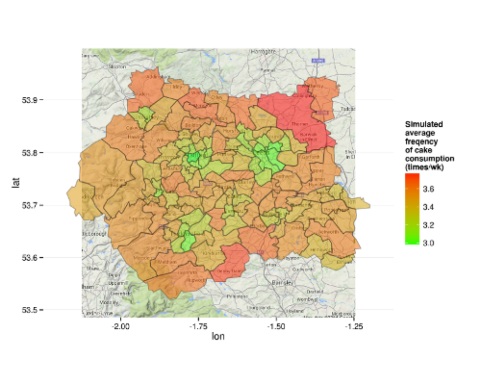

## Analysis and interpretation

Once a spatial microdataset has been generated that we are happy with, we will probably want to analyse it further. This means exploring it — its main features, variability and links with other datasets. To illustrate this process we will load an additional dataset and compare it with the estimates of cake consumption per person generated in the previous section at the ward level.

The hypothesis we would like to test is that cake consumption is linked to deprivation: More deprived people will eat unheathily and cake is a relatively cheap ‘comfort food’. Assuming our simulated data is correct — a questionable assumption but lets roll with it for now — we can explore this at the ward level thanks to a dataset (http://www.neighbourhood.statistics.gov.uk) on modelled income from neighbourhood statistics. The following code is taken from the ‘CakeMapPlot.R’ script.

```r
wards@data <- join(wards@data, imd)
summary(imd$NAME %in% wards$NAME)
##       Mode   FALSE    TRUE    NA's
##    logical      55      71       0
```

The above code first joins the two datasets together and then checks the result by seeing how many matches names there are. In practice the fit between old names and new names is quite poor: only 71 out of 124. In a proper analysis we would have to solve this problem (e.g. via the command `pmatch`, which stands for partial match). For the purposes of this exercise we will simply plot income against simulated cake consumption to gain a feeling what it tells us about the relationship between cake consumption and wealth.

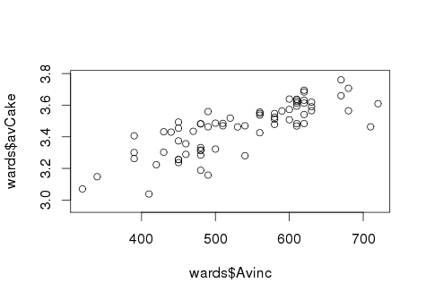

**Scatterplot** illustrating the relationship between modelled average ward income and simulated number of cakes eaten per person per week.

The question raised by this finding is: why? Not why is cake consumption higher in wealthy areas (this has not been established) but: why has the model resulted in this correlation? To explore this question we need to go back and look at the individual level data. The most relevant constraint variable for income was class. When we look at the relationship between social class and cake consumption in the Dental Health Survey, we find that there is indeed a link: individuals in the highest three classes (1.1, 1.2, 2) have an average cake intake of 3.9 cakes per week whereas the three lowest classes have an average intake of 3.7. This is a relatively modest difference but, when averaging over large areas, it helps explain the result.

As a bonus exercise, explore the class dependence of cake consumption in the Dental Health Survey.

# Preparing input data

As with most spatial microsimulation models, this example consists of a non-geographical individual-level dataset and a series of geographical zones. The data used in this chapter (and the data for all other chapters) can be downloaded from the book’s GitHub repository (https://github.com/Robinlovelace/spatial-microsim-book). From this page, click on the ‘Download ZIP’ button to the right of the page and extract the folder into a sensible place on your computer, such as the Desktop. From there, you will want to run R from the project’s root directory: open the folder in a file browser and double click on ‘spatial-microsim-book.Rproj’. This should cause RStudio to be opened at this location, with all the input data files easily accessible to R through *relative file paths*.

The process of loading, checking and preparing the input datasets for spatial microsimulation is generally a linear process, encapsulating the following stages:

1. Load original data
2. Remove excess information
3. Re-categorise individual-level data
4. Set variable and value names
5. ‘Flatten’ individual-level data

‘Stripping down’ the datasets so that they only contain the bare essential information will enable you to focus solely on the data that you are interested in. This is not covered in this chapter because the input datasets are already extremely bare and because the process should be obvious.

We start with the individual-level dataset for a reason: this dataset is often more problematic to format than the constraint variables, so it is worth becoming acquainted with it at the outset. Of course, it is possible that the data you have are not suitable for spatial microsimulation because they lack sufficient constraint variables with shared categories in both individual and aggregate level tables. We assume that you have already checked this. The checking process for the datasets used in this chapter is simple: both aggregate and individual-level tables contain age and sex, so they can by combined. Let us proceed to load some data saved on our hard disc into R’s *environment*, where it is available in memory.

## Loading input data

Real-world individual-level data may be provided in a variety of formats but ultimately needs to be loaded into R as a *data frame* object.

In this case the dataset is loaded from a `.csv` file:

```r
# Load the individual-level data
ind <- read.csv("data/SimpleWorld/ind.csv")
class(ind) # verify the data type of the object
```

```
## [1] "data.frame"
```

```r
ind # print the individual-level data
```

```
##   id age sex
## 1  1  59   m
## 2  2  54   m
## 3  3  35   m
## 4  4  73   f
## 5  5  49   f
```

Constraint data are usually made available one variable at a time, so these are read in one file at a time:

```r
con_age <- read.csv("data/SimpleWorld/age.csv")
con_sex <- read.csv("data/SimpleWorld/sex.csv")
```

We have loaded the aggregate constraints. As with the individual level data, is worth inspecting each object to ensure that they make sense before continuing. Taking a look at `age_con`, we can see that this data set consists of 2 variables for 3 zones:

```r
con_age
```

```
##   a0.49 a.50.
## 1     8     4
## 2     2     8
## 3     7     4
```

This tells us that there 12, 10 and 11 individuals in zones 1, 2 and 3, respectively, with different proportions of young and old people. Zone 2, for example, is heavily dominated by older people: there are 8 people over 50 whilst there are only 2 young people (under 49) in the zone.

Even at this stage there is a potential for errors to be introduced. A classic mistake with areal data is that the order in which zones are loaded changes from one table to the next. The constraint data should therefore come with some kind of *zone id*, an identifying code that will eventually allow the attribute data to be combined with polygon shapes in GIS software.

If we’re sure that the row numbers match between the age and sex tables (we are sure in this case), the next important test is to check that the total populations are equal for both sets of variables. Ideally both the *total* study area populations and *row totals* should match. If the *row totals* match, this is a very good sign that not only confirms that the zones are listed in the same order, but also that each variable is sampling from the same *population base*. These tests are conducted in the following lines of code:

```r
sum(con_age)
```

```
## [1] 33
```

```r
sum(con_sex)
```

```
## [1] 33
```

```r
rowSums(con_age)
```

```
## [1] 12 10 11
```

```r
rowSums(con_sex)
```

```
## [1] 12 10 11
```

```r
rowSums(con_age) == rowSums(con_sex)
```

```
## [1] TRUE TRUE TRUE
```

## Subsetting to remove excess information

In the above code, `data.frame` objects containing precisely the information required for the next stage were loaded. More often, superfluous information will need to be removed from the data and subsets taken. It is worth removing superfluous variables earl, to avoid over-complicating and slowing-down the analysis. For example, if `ind` had 100 variables of which only the 1st, 3rd and 4th were of interest (in that they match the constraint variables), the following command could be used to update the object. Only the relevant variables corresponding to columns (1, 3 and 4 in this case) are retained: `ind <- ind[, c(1, 3, 4)]`. Alternatively, `ind$age <- NULL` removes the age variable.

## Re-cateorising individual-level variables

Before transforming the individual-level dataset `ind` into a form that can be compared with the aggregate-level constraints, we must ensure that each dataset contains the same information. It can be more challenging to re-categorise individual-level variables than to re-name or combine aggregate-level variables, so the former should usually be set first. An obvious difference between the individual and aggregate versions of the `age` variable is that the former is of type `integer` whereas the latter is composed of discrete bins: 0 to 49 and 50+. We can categories the variable into these bins using `cut()`:[^6]

```r
# Test binning the age variable
cut(ind$age, breaks = c(0, 49, 120))
```

```
## [1] (49,120] (49,120] (0,49]   (49,120] (0,49]
## Levels: (0,49] (49,120]
```

If we wanted to change these category labels to something more readable, we can do this by adding another argument to the `cut` function:

```r
# Convert age into a categorical variable with user-chosen labels
(ind$age <- cut(ind$age, breaks = c(0, 49, 120),
  labels = c("a0_49", "a50+")))
```

```
## [1] a50+  a50+  a0_49 a50+  a0_49
## Levels: a0_49 a50+
```

Users should be ware that `cut` results in a vector of class *factor*, which can cause problems later down the line.

## Matching individual and aggregate level data names

Before combining the newly recategorised individual-level data with the aggregate constraints, it is useful to for the category labels to match up. This may seem trivial, but will save time in the long run. Here is the problem:

```r
levels(ind$age)
```

```
## [1] "a0_49" "a50+"
```

```r
names(con_age)
```

```
## [1] "a0.49" "a.50."
```

Note that the names are subtly different. To solve this issue, we can simply change the names of the constraint variable, assuming they are in the correct order:

```r
names(con_age) <- levels(ind$age) # rename aggregate variables
```

With both the age and sex constraint variable names now matching the category labels of the individual-level data, we can proceed to create a single constraint object we label `cons`. We do this with `cbind()`:

```r
cons <- cbind(con_age, con_sex)
cons[1:2, ] # display the constraints for the first two zones
```

```
##   a0_49 a50+ m f
## 1     8    4 6 6
## 2     2    8 4 6
```

## ‘Flattening’ the individual level data

We have made steps towards combining the individual and aggregate datasets and now only need to deal with 2 objects (`ind` and `cons`) which now share category and variable names. However, these datasets cannot possibly be compared because they are of different dimensions:

```r
dim(ind)
```

```
## [1] 5 3
```

```r
dim(cons)
```

```
## [1] 3 4
```

The above code confirms this: we have one individual-level dataset comprising 5 individuals with 3 variables (2 of which are constraint variables and the other an ID) and one aggregate-level constraint table called `cons`, representing 3 zones with count data for 4 categories across 2 variables.

The dimensions of at least one of these objects must change before they can be easily compared. To do this we ‘flatten’ the individual-level dataset; this means increasing its width to match the constraint data. This is a two-stage process. First, `model.matrix()` is used to expand each variable into the number of columns as there are categories in each and assign. Knoblauch and Maloney (2012) provide a lengthier description of this which is available online, for free.

Second, `colSums()` is used to take the sum of each column.[^7]

```r
cat_age <- model.matrix(~ ind$age - 1)
cat_sex <- model.matrix(~ ind$sex - 1)[, c(2, 1)]

 # Combine age and sex category columns into single data frame
(ind_cat <- cbind(cat_age, cat_sex)) # brackets -> print result
```

```
##   ind$agea0_49 ind$agea50+ ind$sexm ind$sexf
## 1            0           1        1        0
## 2            0           1        1        0
## 3            1           0        1        0
## 4            0           1        0        1
## 5            1           0        0        1
```

Note that second call to `model.matrix` is suffixed with `[, c(2, 1)]`. This is to swap the order of the columns: the column variables are produced from `model.matrix` is alphabetic, whereas the order in which the variables have been saved in the constraints object `cons` is `male` then `female`. Such subtleties can be hard to notice yet completely change one’s results so be warned: the output from `model.matrix` will not always be compatible with the constraint variables.

To check that the code worked properly, let’s count the number of individuals represented in the new `ind_cat` variable, using `colSums`:

```r
colSums(ind_cat) # view the aggregated version of ind
```

```
## ind$agea0_49  ind$agea50+     ind$sexm     ind$sexf
##            2            3            3            2
```

```r
ind_agg <- colSums(ind_cat) # save the result
```

The sum of both age and sex variables is 5 (the total number of individuals): it worked! Looking at `ind_agg`, it is also clear that the object has the same ‘width’, or number of columns, `cons`. This means that the individual-level data can now be compared with the aggregate-level data. We can check this by inspecting each object (e.g. via `View(ind_agg)`). A more rigorous test is to see if `ind_agg` can be combined with `ind_agg`, using `rbind`:

```r
rbind(cons[1,], ind_agg) # test compatibility of ind_agg and cons
```

```
##   a0_49 a50+ m f
## 1     8    4 6 6
## 2     2    3 3 2
```

If no error message is displayed on you computer, the answer is yes. This shows us a direct comparison between the number of people in each category of the constraint variables in zone and and in the individual level dataset overall. Clearly, the fit is not very good, with only 5 individuals in total existing in `ind_agg` (the total for each constraint) and 12 in zone 1. We can measure the size of this difference using measures of *goodnes of fit*. A simple measure is total absolute error (TAE), calculated in this case as `sum(abs(cons[1,] - ind_agg))`: the sum of the positive differences between cell values in the individual and aggregate level data.

The purpose of the *reweighting* procedure in spatial microsimulation is to minimise this difference (as measured in TAE above) by adding high weights to the most representative individuals.

# Glossary

This is work in progress.

# Introduction

Spatial microsimulation is a statistical technique for combining individual and geographical data. The resulting *spatial microdata* are useful in many situations where individual-level and geographically specific processes are in operation, enabling modelling and analysis on multiple levels. Spatial microsimulation can also be seen as an approach to better understand the world. The term is little known outside the fields of human geography and regional science yet its methods have the potential to be useful in a wide range of applications. Spatial microsimulation has great potential for informing public policy for social benefit in housing, transport and sustainable urban planning to prepare for a post carbon world — after we stop burning fossil fuels.

There is growing interest in spatial microsimulation. This is due largely to its practical utility in an era of ‘evidence-based policy’ but is also driven by changes in the wider research environment inside and outside of academia. Continued improvements in computers, software and data availability mean spatial microsimulation is more accessible than ever. It is now possible to simulate the populations of small administrative areas at the individual-level almost anywhere in the world. This opens new possibilities for a range of applications, not least policy evaluation.

Still, the meaning of spatial microsimulation is ambiguous for many. This is partly because the technique is inherently difficult to understand and partly due to researchers themselves: some uses of the term in the academic literature are unclear or inconsistent about what the method entails. Worse is work that treats spatial microsimulation as a magical black box. This book is about demystifying spatial microsimulation.

Spatial microsimulation can be understood either as a technique or an approach:

1. A *technique* for generating spatial microdata — individuals allocated to zones (see Figure 1).
2. An *approach* to modelling based on spatial microdata, simulated or real.

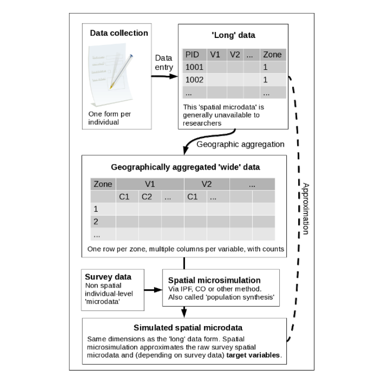

Throughout this book we will see spatial microsimulation in both senses of the term, generally moving from the former to the latter perspective as the chapters progress.

Another issue tackled in this book is reproducibility. Most findings in the field cannot easily be replicated, meaning there is no way of independently checking the results. In today’s age of fast Internet connections, open access datasets and free software, there is little excuse for this. The issue is not unique to the field of spatial microsimulation. Opaque methods, impossible to replicate, are widespread in academia, leading to calls for an ‘Open Regional Science’ (Rey, 2014). Similar proposals made in other research areas seem to be gaining traction (Ince et al., 2012; Peng et al., 2006). This book encourages such a shift towards transparency in the field of spatial microsimulation.

Reproducibility is encouraged throughout via provision of code for readers to actually *do* spatial microsimulation. Small yet realistic datasets are provided to run the methods on your own computer. All the findings presented in this book can therefore be reproduced using code and data in the book’s Github repository: github.com/Robinlovelace/spatial-microsim-book.

Why spend time and effort on reproducibility? The first answer pragmatic: reproducibility can actually save time in the long-run, by ensuring more readable code; reproducibility can increase the re-usability and impact of research, allowing methods to be re-run or modified at a later data. The second reason is more profound: reproducibility is a prerequisite of falsifiability and falsifiability is the backbone of science (Popper, 1959). The results of non-reproducible research cannot be verified, reducing scientific credibility. These philosophical observations inform the book’s practical nature.

This book presents spatial microsimulation as a living, evolving set of techniques rather than a prescriptive formula for arriving at the ‘right’ answer. Spatial microsimulation is largely defined by its user-community, made up of a growing number of people worldwide. This book aims to contribute to the community by encouraging collaboration, innovation and rigour. It also encourages playing with the methods and ‘getting your hands dirty’ with the code. As Kabakoff (2011 p. xxii) put it regarding R, “the best way to learn is to experiment”.

## Why spatial microsimulation with R?

Software decisions have a major impact on the flexibility, efficiency and reproducibility of research. Nearly three decades ago Hölm (1987, p. 153) observed that “little attention is paid to the choice of programming language used” for microsimulation. This appears to be as true now as it was then. Software is rarely discussed in papers on the subject and there are few mature spatial microsimulation packages.[^8] Factors that should influence software selection including cost, maturity, features and performance. Perhaps most important for busy researchers are the ease and speed of learning, writing, adapting and communicating the analysis. R excels in each of these areas, hence the choice of R.

R is a *low-level* language compared with statistical programs based on a strong graphical user interface (GUI) such as Microsoft Excel and SPSS. R offers great flexibility for analysing and modelling data and enables easy creation of user-defined functions. These are all desirable attributes of software for undertaking spatial microsimulation. On the other hand, R is *high-level* compared with general purpose languages such as C and Python. Instead of writing code to perform statistical operations ‘from scratch’, R users generally use pre-made functions. To calculate the mean value of variable `x`, for example, one would need to type 20 characters in Python: `float(sum(x))/len(x)`.[^9] In pure R just 7 characters are sufficient: `mean(x)`. This terseness and range of pre-made functions is useful for ease of reading and writing spatial microsimulation models and analysing the results.

The example of calculating the mean in R and Python may be trite but illustrates a wider point: R was *designed* to work with statistical data, so many functions in the default R installation (e.g. `lm()`, to create a linear regression model) perform statistical analysis ‘out of the box’. In agent-based modelling, the statistical analysis of results often occupies more time than running the model itself (Theile, 2014). The same applies to spatial microsimulation, making R an ideal choice due to its statistical analysis capabilities.

## Learning the R language

A more practical piece of advice is to organise your workflow. Each project should have its own self-contained folder containing all that is needed to replicate the analysis, except perhaps large input datasets. This could include the raw (unchanged) input data[^10], R code for analysis, the graphical outputs and files containing data outputs. To avoid clutter, it is sensible to arrange this content into folders, as illustrated below (thanks to Colin Gillespie for this tip):

```
|-- book.Rmd
|-- data
|-- figures
|-- output
|-- R
|   |-- load.R
|   `-- parallel-ipfp.R
`-- spatial-microsim-book.Rproj
```

The example directory structure above is taken from an early version of this book. It contains the document for the write-up (`book.Rmd` — this could equally be a `.docx` or `.tex` file) and RStudio’s `.Rproj` file in the *source directory*. The rest of the entities are folders: one for the input data, one for figures generated, one for data outputs and one for R scripts. The R scripts should have meaningful names and contain only code that works and is commented. An additional backup directory could be used to store experimental code. There is no need to be prescriptive in following this structure, but projects using spatial microdata tend to be complex, so imposing order over your workflow early will likely yield dividends in the long run.

The same applies to learning the R language. Fluency allows complex numerical ideas to be described with a few keystrokes. If you are a new R user it is therefore worth spending some time learning the R language. To this end the Appendix provides a primer on R from the perspective of spatial microsimulation.

## Typographic conventions

The following typographic conventions are followed to make the practical examples easier to follow:

- In-line code is provided in `monospace` font to show it’s something the computer understands.
- Larger blocks of code, referred to as *listings*, are provided on separate lines and have coloured *syntax highlighting* to distinguish between values, names and functions:

```r
x <- c(1, 2, 5, 10) # create a vector
sqrt(x) # find the square root of x
```

```
## [1] 1.000 1.414 2.236 3.162
```

- Output from the *R console* is preceded by the `##` symbol, as illustrated above.
- Comments are preceded by a single `#` symbol to explain specific lines.
- Often, reference will be made to files contained within the book’s project folder. The notation used to refer to the location of these files follows the way we refer to files and folders on Linux computers. Thus ‘R/CakeMap.R’ refers to a file titled ‘CakeMap.R’, within the ‘R’ directory of the project’s folder.

There are many ways to write R code that will generate the same results. However, to ensure clarity and consistency, a single style, advocated in Hadley Wickham’s *Advanced R* book (http://r-pkgs.had.co.nz/style.html), is followed throughout this book. Consistent style and plentiful comments will make your code readable by yourself and others for decades to come.

## An overview of the book

This document is a working draft of a book to be published in CRC Press’s R Series in summer 2015. Any comments, relating to code, content or clarity of explanation will be gratefully received.[^11]

The structure is as follows:

- *SimpleWorld*, a ‘no nonsense’ and reproducible explanation of spatial microsimulation with reference to an imaginary planet.
- Data preparation, dedicated to the boring but vital task of loading and ‘cleaning’ the input data, ready for spatial microsmulation.
- *Preparing input data*, an introduction to reformatting individual and aggregate-level data ready for spatial microsimulation.
- *Spatial microsimulation in R*, which introduces the main functions and techniques that are used to generate spatial microdata.
- *CakeMap: spatial microsimulation in the wild* is a larger and more involved example using real data.
- *Spatial microdata in agent-based models* describes how the output from spatial microsimulation can be used as an input into more complex models (in progress).
- *Additional tools and techniques* introduces further methods and applications, including a description of R packages for spatial microsimulation (in progress).

# References

Beezer, R. A. (2008). A first course in linear algebra. Puget Sound: Congruent Press.

Edwards, K. L., Clarke, G. P., Thomas, J., & Forman, D. (2010). Internal and External Validation of Spatial Microsimulation Models: Small Area Estimates of Adult Obesity. Applied Spatial Analysis and Policy, 4(4), 281–300. doi:10.1007/s12061-010-9056-2

Feinerer, I. (2013). Introduction to the tm Package Text Mining in R. Comprehensive R Archive Network, 1–8.

Harland, K. (2013). Microsimulation model user guide: flexible modelling framework (No. 0613). Leeds. Retrieved from http://eprints.ncrm.ac.uk/3177/ Knoblauch, K., & Maloney, L. T. (2012). Modeling psychophysical data in R (Vol. 32). Springer.

Lovelace, R., & Ballas, D. (2013). “Truncate, replicate, sample”: A method for creating integer weights for spatial microsimulation. Computers, Environment and Urban Systems, 41, 1–11. doi:10.1016/j.compenvurbsys.2013.03.004

Lovelace, R., & Cheshire, J. (2014). Introduction to visualising spatial data in R. National Centre for Research Methods, 14(03). Retrieved from http://eprints.ncrm.ac.uk/3295/

Meyer, D., Hornik, K., & Feinerer, I. (2008). Text mining infrastructure in R. Journal of Statistical Software, 25(5). Retrieved from http://epub.wu.ac.at/3978/

Pritchard, D. R., & Miller, E. J. (2012). Advances in population synthesis: fitting many attributes per agent and fitting to household and person margins simultaneously. Transportation, 39(3), 685–704. doi:10.1007/s11116-011-9367-4

Rey, S. J. (2014). Open regional science. The Annals of Regional Science, 52(3), 825–837. doi:10.1007/s00168-014-0611-7

Thiele, J. (2014). R Marries NetLogo: Introduction to the RNetLogo Package. Journal of Statistical, 58(2), 1–41. Retrieved from http://www.jstatsoft.org/v58/i02/paper

Venables, W. W. N., Smith, D. M. D. M., Team, R. D. C., & others. (2014). An introduction to R, 1. Retrieved from http://folk.uio.no/bernde/pub/Statistics.pdf Wickham, H. (2014). Advanced R. Retrieved from http://www.crcpress.com/product/isbn/9781466586963

Xie, Y. (2013). Animation: an R package for creating animations and demonstrating statistical methods. Journal of Statistical Software, 53(1), 1–27.

# SimpleWorld

We’ll use an imaginary world called SimpleWorld, consisting of only 3 zones that cover the entirety of the SimpleWorld sphere (Figure 2).

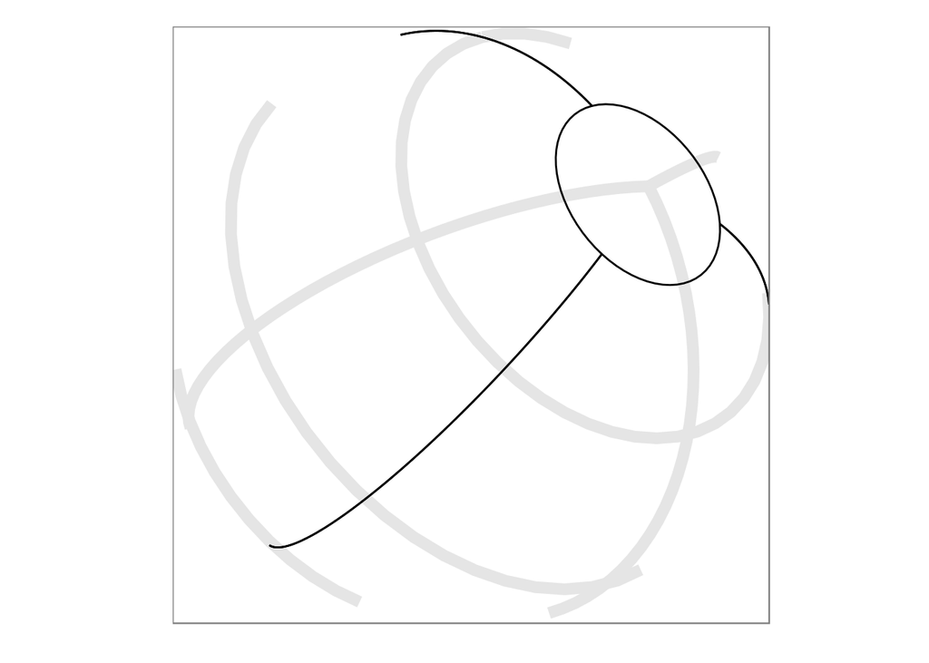

## SimpleWorld data

This is a small world, containing 12, 10 and 11 individuals of its alien inhabitants in zones 1 to 3, respectively: a planetary population of 33. From the SimpleWorld Census, we know how many young (under 49 space years old) and old (over 50) residents live in each zone, as well their genders: male and female. This information is displayed in the tables below.

Aggregate-level age counts for SimpleWorld.

| zone | 0-49 yrs | 50 + yrs |
| --- | --- | --- |
| 1 | 8 | 4 |
| 2 | 2 | 8 |
| 3 | 7 | 4 |

Aggregate sex counts for SimpleWorld.

| Zone | m | f |
| --- | --- | --- |
| 1 | 6 | 6 |
| 2 | 4 | 6 |
| 3 | 3 | 8 |

Next, imagine a more detailed dataset about 5 of SimpleWorld’s inhabitants, recorded from a survey. This is in a different form from the aggregate-level data presented in the above tables. This *microdata* survey contains one row per individual, in contrast to the *aggregate constraints*, which have one row per zone. This individual level data includes exact age (as opposed to the broad categories used in the zone data), as well as income.

Individual-level survey data from SimpleWorld.

| id | age | sex | income |
| --- | --- | --- | --- |
| 1 | 59 | m | 2868 |
| 2 | 54 | m | 2474 |
| 3 | 35 | m | 2231 |
| 4 | 73 | f | 3152 |
| 5 | 49 | f | 2473 |

Note that although the microdataset contains additional information about the inhabitants of SimpleWorld, it lacks geographical information about where each inhabitant lives or even which zone they are from. This is typical of individual-level survey data. Spatial microsimulation tackles this issue by allocating individuals from a non-geographical dataset to geographical zones in another.

## A weight matrix

The procedures we will learn to use in this book do this by allocating *weights* to each individual for each zone. The higher the weight for a particular individual-zone combination, the more representative that individual is of that zone. This information can be represented as a *weight matrix*, such as the one shown below.

A ‘weight matrix’ linking the microdata (rows) to the zones (columns) of SimpleWorld.

| Individual | Zone 1 | Zone 2 | Zone 3 |
| --- | --- | --- | --- |
| 1 | 1.228 | 1.725 | 0.725 |
| 2 | 1.228 | 1.725 | 0.725 |
| 3 | 3.544 | 0.550 | 1.550 |
| 4 | 1.544 | 4.550 | 2.550 |
| 5 | 4.456 | 1.450 | 5.450 |

## Spatial microdata

A more useful output from spatial microsimulation is what we refer to as *spatial microdata*. This is dataset that contains a single row per individual (as with the input microdata) but also an additional variable indicating where each individual lives. The challenge is to ensure that the spatial microdataset is as representative as possible of the aggregate constraints, while only sampling from a realistic baseline population. A feasible combination of individuals sampled from the microdata that represent zone 2 is presented in the table below. The complete spatial microdataset allocates whole individuals to each zone, resulting in a more or less realistic insight into the inhabitants of SimpleWorld. This spatial microdataset is also useful for the purposes of modelling. We will create this table at the end of Chapter 4.

Spatial microdata generated for SimpleWorld zone 2.

| id | zone | age | sex | income |
| --- | --- | --- | --- | --- |
| 1 | 2 | 59 | m | 2868 |
| 2 | 2 | 54 | m | 2474 |
| 4 | 2 | 73 | f | 3152 |
| 4 | 2 | 73 | f | 3152 |
| 4 | 2 | 73 | f | 3152 |
| 4 | 2 | 73 | f | 3152 |
| 5 | 2 | 49 | f | 2473 |
| 4 | 2 | 73 | f | 3152 |
| 5 | 2 | 49 | f | 2473 |
| 2 | 2 | 54 | m | 2474 |

Towards the end of Chapter 4 we will learn how to generate this table from first principles. The remainder of this section considers how the outputs of spatial microsimulation, in the context of SimpleWorld, can be useful before progressing to the practicalities.

## SimpleWorld in context

Even though the datasets are tiny in SimpleWorld, we have already generated some useful output. We can estimate, for example, the average income in each zone. Furthermore, we could create an estimate of the *distribution* of income in each area. Although these estimates are unlikely to be very accurate due to the paucity of data, the methods could be very useful if performed on larger datasets from the RealWorld (planet Earth). Finally, the spatial microdata presented in the above table can be used as an input into an agent-based model (ABM). Assuming the inhabitants of SimpleWorld are more predictable than those of RealWorld, the outputs from such a model could be very useful indeed, for example for predicting future outcomes of current patterns of behaviour.

This Chapter is work in progress.

# Spatial microsimulation in R

In this chapter we progress from loading and preparing the input data to running a spatial microsimulation model. The SimpleWorld data, loaded in the previous chapter, is used. Being small and simple, the example enables understanding the process on a ‘human scale’ and allows experimentation without the worry of overloading your computer. However, the methods apply equally to larger and more complex projects. Therefore practicing the basic principles and methods of spatial microsimulation in R is the focus of this chapter. Time spent mastering these basics will make subsequent steps much easier.

How representative each individual is of each zone is determined by their *weight* for that zone. If we have `nrow(cons)` zones and `nrow(ind)` individuals (3 and 5, respectively, in SimpleWorld) we will create 15 weights. To start, we create an empty weight matrix, ready to be filled with numbers calculated through the IPF procedure:

```r
weights <- matrix(data = NA, nrow = nrow(ind), ncol = nrow(cons))
dim(weights) # dimension of weight matrix: 5 rows by 3 columns
```

```
## [1] 5 3
```

## IPF in R

The most established *deterministic* method to allocate individuals to zones is iterative proportional fitting (IPF). IPF involves calculating a series of weights that represent how representative each individual is of each zone. This is *reweighting*. The IPF algorithm can be written in R from scratch, as illustrated in Lovelace (2014), and as implemented in the smsim-course GitHub repository (https://github.com/Robinlovelace/spatial-microsim-book). The code in this file, and the accompanying text, saves the weight matrix after every constraint for each iteration. While this makes the code relatively slow, it is useful for diagnosing issues with the reweighting process. However, to save computer and researcher time, we will skip directly to an alternative method that uses the **ipfp** package in this section.

Regardless of which implementation of used, IPF can be used to allocate the individual-level data loaded in the previous chapter to the three zones of SimpleWorld. IPF is mature, fast and has a long history. Interested readers are directed towards recent papers (e.g. Lovelace and Ballas, 2012; Pritchard and Miller, 2012) for more detail on the method and its underlying theory.

## Reweighting with **ipfp**

IPF runs much faster and with less code using the **ipfp** package than in pure R. The `ipfp` function runs the IPF algorithm in the C language, taking aggregate constraints, individual level data and and an initial weight vector (`x0`) as inputs:

```r
library(ipfp) # load ipfp library after install.packages("ipfp")
cons <- apply(cons, 2, as.numeric) # to 1d numeric data type
ipfp(cons[1,], t(ind_cat), x0 = rep(1, nrow(ind))) # run IPF
```

```
## [1] 1.228 1.228 3.544 1.544 4.456
```

It is impressive that the entire IPF process, which takes dozens of lines of code in pure R can been condensed into two lines: one to convert the input constraint dataset to `numeric`[^12] and one to perform the IPF operation itself. Note also that although we did not specify how many iterations to run, the above command ran the default of `maxit = 1000` iterations, despite convergence happening after 10 iterations. This can be seen by specifying the `maxit` and `verbose` arguments (the latter of which can be referred to lazily as `v`) in `ipfp`, as illustrated below (only the first line of R output is shown):

```r
ipfp(cons[1,], t(ind_cat), rep(1, nrow(ind)), maxit = 20, v = T)
```

```
## iteration 0:   0.141421
## iteration 1:    0.00367328
## iteration 2:  9.54727e-05
## ...
## iteration 9:  4.96507e-16
## iteration 10:    4.96507e-16
```

Notice also that a *transposed* (via the `t()` function) version of the individual-level data (`ind_cat`) is used in `ipfp` to represent the individual-level data, instead of the `ind_agg` object used in the pure R version. To prevent having to transpose `ind_cat` every time `ipfp` is called, save the transposed version:

```r
ind_catt <- t(ind_cat) # save transposed version of ind_cat
```

Another object that can be saved prior to running `ipfp` on all zones (the rows of `cons`) is `rep(1, nrow(ind))`, simply a series of ones - one for each individual. We will call this object `x0` as its argument name representing the starting point of the weight estimates in `ipfp`:

```r
x0 <- rep(1, nrow(ind)) # save the initial vector
```

To extend this process to all three zones we can wrap the line beginning `ipfp(...)` inside a `for` loop, saving the results each time into the weight variable we created earlier:

```r
weights_maxit_2 <- weights # create a copy of the weights object
for(i in 1:ncol(weights)){
  weights_maxit_2[,i] <- ipfp(cons[i,], ind_catt, x0, maxit = 2)
}
```

The above code uses `i` to iterate through the constraints, one row (zone) at a time, saving the output vector of weights for the individuals into columns of the weight matrix. To make this process even more concise (albeit less clear to R beginners), we can use R’s internal `for` loop, `apply`:

```r
weights <- apply(cons, MARGIN = 1, FUN =
    function(x) ipfp(x, ind_catt, x0, maxit = 20))
```

In the above code R iterates through each row (hence the second argument `MARGIN` being `1`, `MARGIN = 2` would signify column-wise iteration). Thus `ipfp` is applied to each zone in turn, as with the `for` loop implementation. The speed savings of writing the function with different configurations are benchmarked in ‘parallel-ipfp.R’ in the ‘R’ folder of the book project directory. This shows that reducing the maximum iterations of `ipfp` from the default 1000 to 20 has the greatest performance benefit.[^13] To make the code run faster on large datasets, a parallel version of `apply` called `parApply` can be used. This is also tested in ‘parallel-ipfp.R’.

It is important to check that the weights obtained from IPF make sense. To do this, we multiply the weights of each individual by rows of the `ind_cat` matrix, for each zone. Again, this can be done using a for loop, but the apply method is more concise:

```r
ind_agg <- t(apply(weights, 2, function(x) colSums(x * ind_cat)))
colnames(ind_agg) <- colnames(cons) # make the column names equal
```

As a preliminary test of fit, it makes sense to check a sample of the aggregated weighted data (`ind_agg`) against the same sample of the constraints. Let’s look at the results (one would use a subset of the results, e.g. `ind_agg[1:3, 1:5] for the first five values of the first 3 zones for larger constraint tables found in the real world):

```r
ind_agg
```

```
##      a0_49 a50+ m f
## [1,]     8    4 6 6
## [2,]     2    8 4 6
## [3,]     7    4 3 8
```

```r
cons
```

```
##      a0_49 a50+ m f
## [1,]     8    4 6 6
## [2,]     2    8 4 6
## [3,]     7    4 3 8
```

```r
# Re-allocate the values of ind_agg (not column names - note '[]')
ind_agg[] <- t(apply(weights_maxit_2, MARGIN = 2,
  FUN = function(x) colSums(x * ind_cat)))
ind_agg[1:2, 1:3]
```

```
##      a0_49  a50+ m
## [1,] 8.003 3.997 6
## [2,] 2.004 7.996 4
```

## Alternative reweighting algorithms

As described in the Introduction, IPF is just one strategy for obtaining a spatial microdataset. However, researchers (myself included) have tended to select one method that they are comfortable and stick with that for their models. This is understandable because setting-up the method is usually time consuming: most researchers rightly focus on applying the methods to the real world rather than fretting about the details. On the other hand, if alternative methods work better for a particular application, resistance to change can result in poor model fit. In the case of very large datasets, spatial microsimulation may not be possible unless certain methods, optimised to deal with large datasets, are used. Above all, there is no consensus about which methods are ‘best’ for different applications, so it is worth experimenting to identify which method is most suitable for each application.

### Spatial microsimulation as an objective function

In general terms, an *objective function* is a formula that processes a series of input variables ($x$) using a number of parameters ($par$) to generate a single numeric output:

$\mbox{minimise } f_0(x)$

$\mbox{subject to } f_i(x) \leq par_i,\ i = 1, ..., m$

The goal of objective function $f_0$ such as that illustrated above is to enable the selection of the parameters $par_i$ to $par_m$ which minimize the result. The values that parameters may take are constrained by *constraint functions* ($f_i$) or fixed values (Boyd and Vandenberghe, 2009). The case of spatial microsimulation has relatively simple constraints: they are all positive or zero. Seeing spatial microsimulation as an objective function allows solutions to be found using established techniques of *constrained optimisation*. The main advantage of this re-framing is that it allows any optimisation algorithm to perform the reweighting. Key to this is interpreting individual weights as parameters (the vector $par$, of length $m$ above) that are iteratively modified to optimise the fit between individual and aggregate-level data. The measure of fit is we use in this context is Total Absolute Error (TAE) and the objective function is as follows:

$\mbox{minimise }f(par) = TAE(sim, con)$

$\mbox{where }sim = colSums(ind\_cat * par)$

$\mbox{subject to } par \geq 0$

Note that in the above, $par$ is equivalent to the `weights` object we have created in previous sections to represent how representative each individual is of each zone. The main issue with this definition of reweighting is therefore the large number of free parameters: equal to the number of individual-level dataset. Clearly this can be very very large. To overcome this issue, we must ‘compress’ the individual level dataset to its essence, to contain only unique individuals with respect to the constraint variables (*constraint-unique* individuals).

### Reweighting with optim and GenSA

The base R function `optim` provides a general purpose optimisation framework for numerically solving objective functions. Based on the objective function for spatial microsimulation described above, we can use any general optimisation algorithm for reweighting the individual-level dataset. But which to use?

Different reweighting strategies are suitable in different contexts and there is no clear winner for every occasion. However, testing a range of strategy makes it clear that certain algorithms are more efficient than others for spatial microsimulation. Figure x demonstrates this variability by plotting total absolute error as a function of number of iterations for various optimisation algorithms available from the base function `optim` and the **GenSA** package.

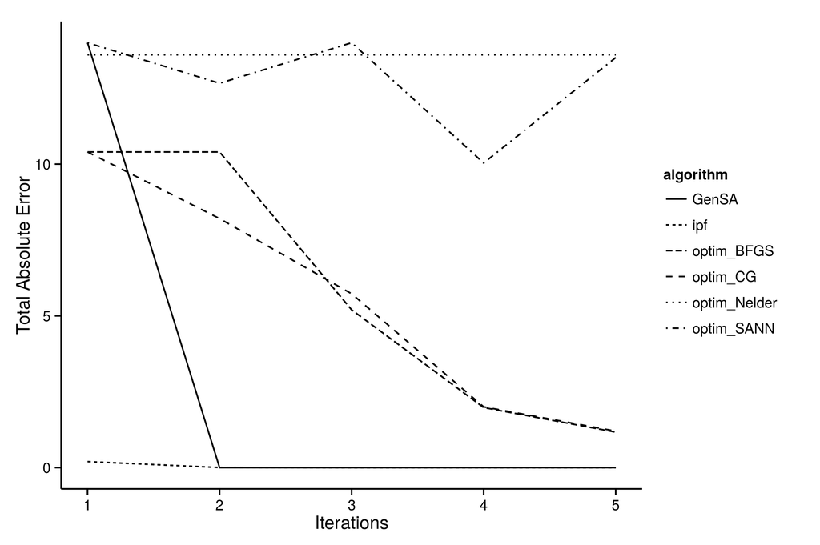

Figure x shows the advantage of the IPF algorithm we have been using, which converges rapidly to zero error after only a few iterations. On the other end of the spectrum is R’s default optimisation algorithm, the Nelder-Mead method. Although the graph shows no improvement from one iteration to the next, it should be stated that the algorithm is just ‘warming up’ at this stage and than each iteration is very fast, as we shall see. After a few *hundred* iterations (which happen in the same time that other algorithms take for a single iteration), the Nelder-Mead method is effective, converging to close to zero in 400 iterations, taking far more iterations to converge to a value approximating zero than IPF. Next best in terms of iterations is `GenSA`, the Generalized Simulated Annealing Function from the **GenSA** package. GenSA attained a near-perfect fit after only two full iterations.

The remaining algorithms shown are, like Nelder-Mead, available from within R’s default optimisation function `optim`. The implementations with `method =` set to `"BFGS"` (short for the Broyden–Fletcher–Goldfarb–Shanno algorithm), `"CG"` (‘conjugate gradients’) performed roughly the same, steadily approaching but not reaching zero error after five iterations. Finally, the `SANN` method, also available in `optim`, performed most erratically of the methods tested. This is another implementation of simulated annealing which demonstrates that optimisiation functions that depend on random numbers do not always lead to improved fit from one iteration to the next.

The code used to test these alternative methods for reweighting are provided in the script ‘R/optim-tests-SimpleWorld.R’. The results should be reproducible on any computer, provided the book’s supplementary materials have been downloaded. There are many other optimisation algorithms available in R through a wide range of packages; new and improved functions are available all the time so enthusiastic readers are encouraged to experiment with this script files: it is perfectly feasible that an algorithm exists which outperforms all of those tested for this book. Also, it should be noted that the algorithms were tested on the extremely simple and rather contrived example dataset of SimpleWorld. Some algorithms perform better with larger datasets than others and the results can be highly sensitive to changes to the initial conditions such as the problem of ‘empty cells’.

Therefore these results, as with any modelling exercise, should be interpreted with a healthy dose of skepticism: just because an algorithm converges after few ‘iterations’ this does not mean it is inherently any faster or more useful than another. The results are context specific, so it is recommended that the tested framework in ‘R/optim-tests-SimpleWorld.R’ is used as a basis for further tests on algorithm performance on the datasets you are using. IPF has performed well in the situations I have tested it in (especially via the `ipfp` function, which performs disproportionately faster than the pure R implementation on large datasets) but this does not mean that it is always the best approach.

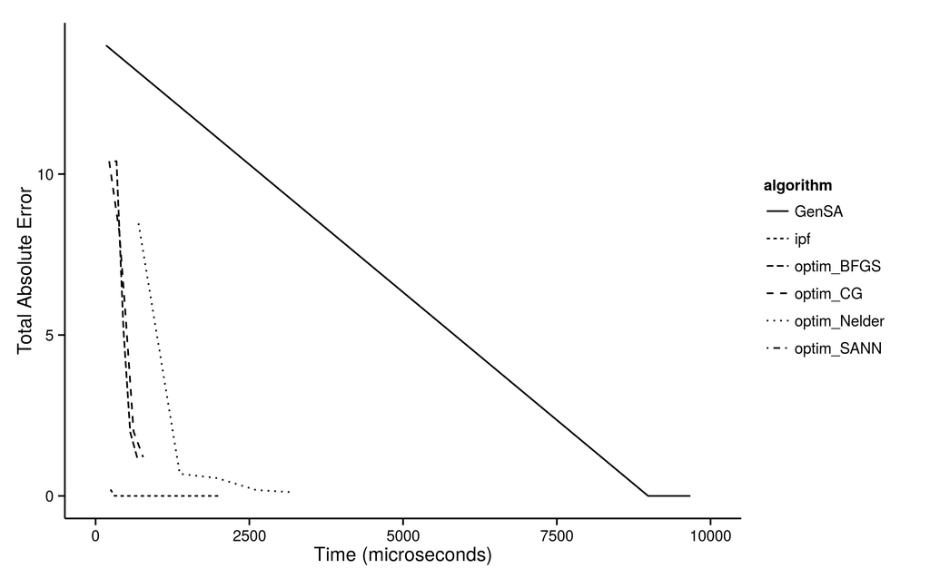

### Combinatorial optimisation

Combinatorial optimisation is an alternative to IPF for allocating individuals to zones. This strategy is *probabilistic* and results in integer weights, as opposed to the fractional weights generated by IPF. Combinatorial optimisation may be more appropriate for applications where input individual microdatasets are very large: the speed benefits of using the deterministic IPF algorithm shrink as the size of the survey dataset increases. An alternative to combinatorial optimisation, which builds on the fractional weights generated through IPF (or any other method of reweighting), is *intersation*. Integerisation largely reduces the need for combinatorial optimisation, as we shall see in the next section ().

The second approach to combinatorial optimisation in R depends on methods that allow only integer solutions to the general constrained optimisation formulae demonstrated in the previous section. *Integer programming* is the branch of computer science dedicated to this area, and it is associated with its own algorithms and approaches, some of which have been implemented in R (Zubizarreta, 2012).

To illustrate how the approach works in general terms, we can use the `data.type.int` argument of the `genoud` function in the **rgenoud** package. This ensures only integer results for a genetic algorithm to select parameters are selected:

```r
set.seed(2014)
genoud(nvars = nrow(indu), fn = fun, ind_num = indu, con = cons[1,],
  control = list(maxit = 1000), data.type.int = TRUE,

  # Set min and maximum values of constraints with 'Domains'
  D = matrix(c(rep(0, nrow(indu)),rep(100, nrow(indu))), ncol = 2))
```

This rather long command, implemented in ‘optim-tests-SimpleWorld.R’, results in weights for the unique individuals 1 to 4 of 1, 4, 2 and 4 respectively. This means that a total population of 11 individuals is simulated for the zone, composed of 1 instance of individual 1 and ‘clones’ of the others. Given that the command takes 5 seconds to generate weights for only 4 unique individuals, and the fact that there are in fact 12 not 11 individuals in zone 1 in SimpleWorld, this implementation of `genoud` is clearly not production ready. `genoud` is used here to provide a practical demonstration of the possibilities of combinatorial optimisation in R, an area that has great potential to advance in the future.

For combinatorial optimisation algorithms designed for spatial microsimulation we must, for now, look for programs outside the R ‘ecosystem’. Harland (2013) provides a practical tutorial introducing the subject based on the Flexible Modelling Framework (FMF) Java program. It is possible to generate integer spatial microdata using IPF, however, using a technique we refer to imaginatively as integerisation. This is the topic of the next section.

## Integerisation

Integerisation is the process by which a vector of real numbers is converted into a vector of integers corresponding to the individuals present in synthetic spatial microdata. The length of the new vector must equal the population of the zone in question and individuals with high weights must be sampled proportionally more frequently than those with low weights for the operation to be effective. The following example illustrates how the process, when seen as a function called $int$ would work on a vector of 3 weights:

$w_1 = (0.333, 0.667, 3)$

$int(w_1) = (2, 3, 3, 3)$

This result was obtained by calculating the sum of the weights (4, which represents the total population of the zone) and sampling from these until the total population is reached. In this case individual 2 is selected once as they have a weight approaching 1, individual 3 was replicated (*cloned*) three times and individual 1 does not appear in the integerised dataset at all, as it has a low weight. In this case the outcome is straightforward because the numbers are small and simple. But what about in less clear-cut cases, such as $w_2 = (1.333, 1.333, 1.333)$? What is needed is an algorithm to undertake this process of *integerisation* in a systematic way to maximise the fit between the synthetic and constraint data for each zone.

In fact there are a number of integerisation strategies available. Lovelace and Ballas (2012) tested 5 of these and found that probabilistic integerisation methods consistently outperformed deterministic rivals. The details of these algorithms are described in the aforementioned paper and code is provided in the Supplementary Information. For the purposes of this course we will create a function to undertake the simplest of these, *proportional probabilities*:

```r
int_pp <- function(x){
  sample(length(x), size = round(sum(x)), prob = x, replace = T)
}
```

To test this function let’s try it on the vectors of length 3 described in code:

```r
set.seed(0)
int_pp(x = c(0.333, 0.667, 3))
```

```
## [1] 2 3 3 3
```

```r
int_pp(x = c(1.333, 1.333, 1.333))
```

```
## [1] 1 2 1 1
```

The first result was the same as that obtained through intuition; the second result represented individual 1 being clones three times, plus one instance of individual 2. This is not intuitive: one would expect at least one of each individual given that they all have the same weight.

It is important to emphasise that the results will change each time the code is run, because `sample` is a probabilistic (its output depends on a random number generator): changing the value inside the brackets proceeding `set.seed` results in many other combinations of individuals being selected — test this out in your code. This happens because the method relies on *pseudo random numbers* to select values probabilistically and `set.seed` specifies where the random number sequence should begin, ensuring repeat-ability. An issue with the *proportional probabilities* (PP) strategy is that completely unrepresentative combinations of individuals have a non-zero probability of being sampled: the method will output $(1, 1, 1, 1)$ once in every 21 thousand runs for $w_1$ and once every $81$ runs for $w_2$, the same probability as for all other 81 ($3^4$) permutations.

To overcome this issue Lovelace and Ballas (2012) developed a method which ensures that any individual with a weight above 1 would be sampled at least once, making the result $(1, 1, 1, 1)$ impossible in both cases. This method is *truncate, replicate, sample* (TRS) integerisation:

```r
int_trs <- function(x){
  truncated <- which(x >= 1)
  replicated <- rep(truncated, floor(x[truncated]))
  r <- x - floor(x)
  def <- round(sum(x)) - length(replicated) # deficit population
  if(def == 0){
    out <- replicated
  } else {
    out <- c(replicated,
      sample(length(x), size = def, prob = r, replace = FALSE))
  }
  out
}
```

To see how this new integerisation method and associated R function performed, we will run it on the same input vectors:

```r
int_trs(c(0.333, 0.667, 3))
```

```
## [1] 3 3 3 2
```

```r
int_trs(c(1.333, 1.333, 1.333))
```

```
## [1] 1 2 3 3
```

The range of possible outcomes is smaller using the TRS technique; the fit between the resulting microdata and the aggregate constraints will tend to be higher. Thus we use the TRS methodology, implemented through the function `int_trs`, for integerising the weights generated by IPF throughout the majority of this book.

Let’s use TRS to generate spatial microdata for SimpleWorld. Remember, we already have generated the weight matrix `weights`. The only challenge is to save the vector of sampled individual id numbers, alongside the zone number, into a single object from which the attributes of these individuals can be recovered. Two strategies for doing this are presented in the code below:

```r
# Method 1: using a for loop
ints_df <- NULL
for(i in 1:nrow(cons)){
  ints <- int_trs(weights[, i])
  ints_df <- rbind(ints_df, data.frame(id = ints, zone = i))
}

# Method 2: using apply
ints <- unlist(apply(weights, 2, int_trs)) # integerised result
ints_df <- data.frame(id = ints,
  zone = rep(1:nrow(cons), colSums(weights)))
```

Both methods yield the same result for `ints_df`. The only differences being that Method 1 is perhaps more explicit and easier to understand whilst Method 2 is more concise.

```r
ind_full <- read.csv("data/SimpleWorld/ind-full.csv")
library(dplyr) # use install.packages(dplyr) if not installed
ints_df <- inner_join(ints_df, ind_full)
```

`ints_df` represents the final spatial microdataset, representing the entirety of SimpleWorld’s population of 33 (this can be confirmed with `nrow(ints_df)`). To select individuals from one zone only is simple using R’s subsetting notation. To select all individuals generated for zone 2, for example, the following code is used. Note that this is the same as the output generated in Table 5 at the end of the SimpleWorld chapter — we have successfully modelled the inhabitants of a fictional planet, including income!

```r
ints_df[ints_df$zone == 2, ]
```

```
##    id zone age sex income
## 13  1    2  59   m   2868
## 14  2    2  54   m   2474
## 15  4    2  73   f   3152
## 16  4    2  73   f   3152
## 17  4    2  73   f   3152
## 18  4    2  73   f   3152
## 19  5    2  49   f   2473
## 20  4    2  73   f   3152
## 21  5    2  49   f   2473
## 22  2    2  54   m   2474
```

# What is spatial microsimulation?

Spatial microsimulation is a statistical technique for allocating individuals from a survey dataset to administrative zones, based on shared variables between the areal and individual level data. As with many new and infrequently used phrases, this understanding is not shared by everyone. The meaning of spatial microsimulation varies depending on context and who you ask. To an economist, spatial microsimulation is likely to imply modelling some kind of temporal process such as how individual agents in different areas respond to changes in prices or policies. To a transport planner, the term may imply simulating the precise movements of vehicles on the transport network. To your next door neighbour it may mean you have started speaking gobbledygook! Hence the need to consider what spatial microsimulation is, and what it is not, at the outset.

## Terminology

Delving a little into the etymology and history of the term reveals the reasons behind this duplicity of meaning and highlights the importance of terminology. Rarely will you be understood saying “I use *spatial microsimulation*” in everyday life. Usually it is important to add context. Below are a few hypothetical situations and suggested responses.

- When talking to a colleague, a transport modeller: “spatial microsimulation, also known as population synthesis…”
- Speaking to agent based modellers: “we use spatial microsimulation to simulate the characteristics of geo-referenced agents…”
- Communicating with undergraduates who are unlikely to have come across the term or its analogies. “I do spatial microsimulation, a way of generating individual-level data for small areas…”
- Chatting casually in the pub or coffee shop: “I’m using a technique called spatial microsimulation to model people…”.

The above examples illustrate potential for confusion: care needs to be taken to use terminology each audience understands. The transport modeller, for example, may already know that the term ‘population synthesis’ means creating an individual-level dataset of real areas, whereas more basic terms need to be used when communicating the method to policy makers. All this links back to the importance of transparency and reproducibility of method discussed in the previous chapter: avoid implying spatial microsimulation is something it is not.

Faced with uncomprehending stares when describing the method, some may be tempted to ‘blind them with science’, relying on sophisticated-sounding jargon, for example by saying: “we use simulated annealing in our integerised spatial microsimulation model”. Such wording obscures meaning (how many people in the room will understand ‘integerised’, let alone ‘simulated annealing’) and makes the process inaccessible. Although much jargon is used in the spatial microsimulation literature and in this book, care must be taken to ensure that people understand what you are saying.

This raises the question, why use the term spatial microsimulation at all, if it is understood by so few people? The answer to this is that spatial microsimulation, defined clearly at the outset and used correctly, can concisely describe a technique that would otherwise need many more words on each use. Try replacing ‘spatial microsimulation’ with ‘a statistical technique to allocate individuals from a survey dataset to administrative zones’ each time it appears in this book and the advantages of a simple term should become clear! ‘Population synthesis’ is perhaps a more accurate term but, transport modelling aside, the literature already uses ‘spatial microsimulation’. Rather than create more complexity with *another* piece of jargon, we proceed with the term favoured by the majority of practitioners.

Why has this situation, in which practitioners of a statistical method must tread carefully to avoid confusing their audience, come about? First it’s worth stating that the problem is by no means unique to this field: imagine the difficulties that Bayesian statisticians must encounter when speaking of prior and posterior probability distributions to an uninitiated audience. Let alone describing Gibb’s sampling.

To avoid confusion regarding the terminology used in this book, a glossary defining much of the jargon relating to spatial microsimulation is provided at the end. For now, to help answer what spatial microsimulation is we will look at its applications and then at what it is not.

## Applications

Spatial microsimulation has a wide variety of applications and there are many areas where the technique has been used. Some of the main areas of application have been health, economic policy evaluation and transport. Rather than attempt to provide a comprehensive account of the range of current and possible applications, this section describes a single study in each area to exemplify how spatial microsimulation is used.

### Economic policy evaluation

## What spatial microsimulation is not

**Spatial microsimulation is not strictly spatial**

The most surprising feature of spatial microsimulation is that the method is not strictly *spatial*. The only reason why the method has developed this name (as opposed to ‘small area population synthesis’, for example) is that practitioners tend to use administrative zones, which represent geographical areas, as the grouping variable. However, any mutually exclusive grouping variable, such as age band or number of bedrooms in your house, could be used. Likewise, geographical location can be used as a *constraint variable*. In most spatial microsimulation models, the spatial variable is a mutually exclusive grouping, interchangeable with any such group. Of course, the spatial microdata, maps and analysis that result from spatial microsimulation are spatial, it’s just that there is nothing inherently spatial about the method used to generate the spatial microdata.

To be more precise, spatial microsimulation is not *inherently spatial*. Spatial attributes such as the geographic coordinates of the zones to which individuals have been allocated and home and work locations can easily be added to the spatial microdata after they have been generated. It is the use of geographical variables as the grouping variable that is critical here and which distinguishes spatial microsimulation from other types of microsimulation.

**Spatial microsimulation is not agent-based modelling (ABM).**

Spatial microsimulation does involve the creation and analysis of individuals, but it does not imply any interaction between these individuals. For this, an agent-based model (ABM) is needed. It would be easy to assume that because the method contains the word ‘simulation’, it includes modelling of individual behaviours over time and space. This is not the case.

Spatial microsimulation as an approach to modelling involves what-if scenarios, the allocation of individuals to specific zones and, in some cases, a time step to represent the individuals’ evolution over time. Agent based modelling, by contrast imply some kind of interaction between the individual units. Spatial microsimulation is closely linked to ABM, however. As described in Chapter , the outputs of spatial microsimulation form an excellent basis for ABMs.

**Spatial microsimulation does not generate new data**

During spatial microsimulation, apparently new individuals are created and placed into zones. It would be tempting to think that new information about the world is somehow being created. This is not the case: the ‘new’ individuals are simply repeats of individuals we already knew about from the individual-level data, albeit in a different order and in different combinations. If the population of the study area is greater than the sample size of the input data, many individuals will have to be ‘cloned’. Thus we are not increasing the diversity of the dataset, simply changing its aggregate-level characteristics.

## Assumptions

As with any simulation technique, spatial microsimulation is based on assumptions, some of which are unlikely to hold in all cases. This does not preclude spatial microsimulation in cases where the assumptions do not hold: “It is far better to foresee even without certainty than not to foresee at all”, as Henri Poincaré put it (Barthélemy, 2014). It is vital, however, that users of spatial microsimulation and ‘consumers’ of the resulting research understand that the results of spatial microsimulation are not *real* but a best estimate of the population in a given area. The danger is that if the assumptions are not understood, incorrect conclusions will result. It is therefore the duty of researchers using spatial microsimulation (and other techniques) to clearly state the assumptions on which the results depend on and the extent to which these assumptions can be expected to hold in practice. Roughly speaking there are four main assumptions underlying all spatial microsimulation models:

1. The individual-level microdata are representative of the study area.
2. The target variable is dependent on the constraint variables and their interactions in a way that is relatively constant over space and time.
3. The relationships between the constraint variables are not spatially dependent.
4. The input microdataset and constraints are sufficiently rich and detailed to reproduce the full diversity of individuals and areas in the study region.

Obviously the real world is complex and many processes are spatially dependent, invalidating assumptions 2 and 3. The extent to which the relationships between variables can be deemed to be constant over space is often unknown. However, there there are ways of checking the spatial dependency of relationships between multiply variables, not least Geographically Weighted Regression (GWR). In any case, these limitations should be discussed at the outset of spatial microsimulation research, with reference to the input data. To see how spatial microsimulation simplifies the real world, the next chapter describes a hypothetical scenario where 33 inhabitants of an imaginary land are simulated and allocated to three zones based on a microdataset of only 5 individuals and two constraint variables.

[^1]: We can get the right answer in Python, by typing the following: `import numpy; a=numpy.array([1,2,3]); b=numpy.array([9,8,6]); a+b`.
[^2]: This can be ascertained by typing `class(ind)`. It is useful to know the class of different R objects, so make good use of the `class()` function.
[^3]: Thus, yet another way to invoke the 2nd column of `ind` is the following: `ind[c(F, T, F)]`! Here, `T` and `F` are shorthand for “TRUE” and “FALSE” respectively.
[^4]: R tip: This information can be seen, once the dataset is loaded, by entering `unique(ind$ageband4)` or, to see the counts in each category, `summary(ind$ageband4)`. Because the variable is of type `factor`, `levels(ind$ageband4)` will also provide this information.
[^5]: Data frames will not work in this function and must be converted to matrices with `as.matrix`.
[^6]: The combination of curved and square brackets in the output may seem strange but this is in fact an International Standard - see http://en.wikipedia.org/wiki/ISO_31-11 for more information.
[^7]: As we shall see in Section , only the former of these is needed if we use the **ipfp** package for re-weighting the data, but both are presented to enable a better understanding of how IPF works.
[^8]: The Flexible Modelling Framework (FMF) (https://github.com/MassAtLeeds/FMF) is a notable exception written in Java that can perform various modelling tasks.
[^9]: The `float` function is needed in case whole numbers are used. This can be reduced to 13 characters with the excellent **NumPy** package: `import numpy; x = [1,3,9]; numpy.mean(x)` would generate the desired result. The R equivalent is `x = c(1,3,9); mean(x)`.
[^10]: Raw data should be kept safely on an external hard disk or a server if it is large or sensitive.
[^11]: Feedback can be left via email to r.lovelace@leeds.ac.uk or via the project’s GitHub page (http://github.com/Robinlovelace/spatial-microsim-book).
[^12]: The integer data type fails because C requires `numeric` data to be converted into its *floating point* data class.
[^13]: These tests also show that any speed gains from using `apply` instead of `for` are negligible, so whether to use `for` or `apply` can be decided by personal preference.
[^14]: The functions `merge` from the R’s base package and `join` from the **plyr** provide other ways of undertaking this step. `inner_join` is used in place of `merge` because `merge` does not maintain row order. `join` generates the same result, but is slower, hence the use of `inner_join` from the recently released and powerful **dplyr** package.